# An Empirical Analysis of Traffic Collisions in New York City

[figure not shown]

#### Data Analysis and Applied Social Research

Queens College, CUNY  
Spring 2019; Project II  
Jennifer Ganeles, Abigail Strick, Afzal Hossain

## 1. Importing Modules:

```python
# For matplotlib graphs to be included in our notebook:
%matplotlib inline

# For data manipulation:
import pandas as pd

# For scientific computing:
import numpy as np

#For using operating system dependent functionality:
import os

# For plotting:
import matplotlib.pyplot as plt

# matplotlib.patches allows us to create colored patches:
import matplotlib.patches as mpatches

#For more beautiful plots:
import seaborn as sns

# For changing the figure size:
from matplotlib.pyplot import figure

# Setting up working directory:
os.chdir("C:/Users/Afzal Hossain/Documents/A.Spring 2019/SOC 765_DataScience/SOC765_Project")
```

## 2. Importing and Setting Up Our Data:

```python
#Reading in our CSV data:
collisions_df = pd.read_csv("NYPD_Motor_Vehicle_Collisions.csv",low_memory=False)

#Looking at the first few rows of our dataset:
collisions_df.head()
```

|  | DATE | TIME | BOROUGH | ZIP CODE | LATITUDE | LONGITUDE | LOCATION | ON STREET NAME | CROSS STREET NAME | OFF STREET NAME | ... | CONTRIBUTING FACTOR VEHICLE 2 | CONTRIBUTING FACTOR VEHICLE 3 | CONTRIBUTING FACTOR VEHICLE 4 | CONTRIBUTING FACTOR VEHICLE 5 | UNIQUE KEY | VEHICLE TYPE CODE 1 | VEHICLE TYPE CODE 2 | VEHICLE TYPE CODE 3 | VEHICLE TYPE CODE 4 | VEHICLE TYPE CODE 5 |
| --- | --- | --- | --- | --- | --- | --- | --- | --- | --- | --- | --- | --- | --- | --- | --- | --- | --- | --- | --- | --- | --- |
| 0 | 02/09/2019 | 0:00 | MANHATTAN | 10014 | 40.735664 | -74.001620 | (40.735664, -74.00162) | NaN | NaN | 159 7 AVENUE SOUTH | ... | Unspecified | NaN | NaN | NaN | 4077646 | Station Wagon/Sport Utility Vehicle | Sedan | NaN | NaN | NaN |
| 1 | 02/09/2019 | 0:00 | BROOKLYN | 11206 | 40.705017 | -73.949480 | (40.705017, -73.94948) | BROADWAY | LYNCH STREET | NaN | ... | Unspecified | NaN | NaN | NaN | 4078490 | Station Wagon/Sport Utility Vehicle | Station Wagon/Sport Utility Vehicle | NaN | NaN | NaN |
| 2 | 02/09/2019 | 0:03 | MANHATTAN | 10016 | 40.742290 | -73.974594 | (40.74229, -73.974594) | NaN | NaN | 550 1 AVENUE | ... | Driver Inattention/Distraction | NaN | NaN | NaN | 4077405 | Station Wagon/Sport Utility Vehicle | Taxi | NaN | NaN | NaN |
| 3 | 02/09/2019 | 0:05 | MANHATTAN | 10038 | 40.709953 | -74.009010 | (40.709953, -74.00901) | NaN | NaN | 15 JOHN STREET | ... | Unspecified | NaN | NaN | NaN | 4077380 | Garbage or Refuse | Station Wagon/Sport Utility Vehicle | NaN | NaN | NaN |
| 4 | 02/09/2019 | 0:14 | MANHATTAN | 10039 | 40.825897 | -73.939360 | (40.825897, -73.93936) | WEST 150 STREET | MACOMBS PLACE | NaN | ... | Unspecified | NaN | NaN | NaN | 4078207 | Station Wagon/Sport Utility Vehicle | Station Wagon/Sport Utility Vehicle | NaN | NaN | NaN |

5 rows × 29 columns

## 3. Data Cleaning:

#### i) Getting Rid of Space in Columns:

```python
# Replacing all the column names that contain a space with "_" so we can use the '.' notation:
collisions_df.columns = collisions_df.columns.str.replace(" ", "_")
collisions_df.columns
```

```
Index(['DATE', 'TIME', 'BOROUGH', 'ZIP_CODE', 'LATITUDE', 'LONGITUDE',
       'LOCATION', 'ON_STREET_NAME', 'CROSS_STREET_NAME', 'OFF_STREET_NAME',
       'NUMBER_OF_PERSONS_INJURED', 'NUMBER_OF_PERSONS_KILLED',
       'NUMBER_OF_PEDESTRIANS_INJURED', 'NUMBER_OF_PEDESTRIANS_KILLED',
       'NUMBER_OF_CYCLIST_INJURED', 'NUMBER_OF_CYCLIST_KILLED',
       'NUMBER_OF_MOTORIST_INJURED', 'NUMBER_OF_MOTORIST_KILLED',
       'CONTRIBUTING_FACTOR_VEHICLE_1', 'CONTRIBUTING_FACTOR_VEHICLE_2',
       'CONTRIBUTING_FACTOR_VEHICLE_3', 'CONTRIBUTING_FACTOR_VEHICLE_4',
       'CONTRIBUTING_FACTOR_VEHICLE_5', 'UNIQUE_KEY', 'VEHICLE_TYPE_CODE_1',
       'VEHICLE_TYPE_CODE_2', 'VEHICLE_TYPE_CODE_3', 'VEHICLE_TYPE_CODE_4',
       'VEHICLE_TYPE_CODE_5'],
      dtype='object')
```

#### ii. Renaming Variables in Columns `ON_STREET_NAME` & `VEHICLE_TYPE_CODE_1` and Getting Rid of Spaces:

```python
# List of bad street names that exist in dataset:
bad_name=['av', 'av', 'av', 'st', 'rd', 'blvd', 'pl', 'pl', 'sq', 'dr', 'ln', 'pkwy', 'tp', 'ter', '1', '2', '3', '1', '2', '3', '4', '5', '6', '7', '8', '9', '0', 'w ', 'n ', 'e ', 's ']

# List of names that we wanted to convert:
good_name =['avenue', 'ave', 'avnue', 'street', 'road', 'boulevard', 'place', 'plaza', 'square', 'drive', 'lane', 'parkway', 'turnpike', 'terrace', '1st', '2nd', '3rd', '1th', '2th', '3th', '4th', '5th', '6th', '7th', '8th', '9th', '0th', 'west ', 'north ', 'east ', 'south ']

# Replacing the street names in the dataset using our lists:
collisions_df['ON_STREET_NAME']=collisions_df['ON_STREET_NAME'].replace(bad_name,good_name)

#Getting Rid of Space[e.g: "1 AVENUE      " to "1 AVENUE"]:
collisions_df['ON_STREET_NAME']=collisions_df.ON_STREET_NAME.str.strip()

# Replacing the Vehicle Type:
collisions_df['VEHICLE_TYPE_CODE_1']=collisions_df.VEHICLE_TYPE_CODE_1.replace(["Taxi","Bus","Station Wagon/Sport Utility Vehicle"],['TAXI','BUS',"SPORT UTILITY / STATION WAGON"])

#Getting Rid of Space:
collisions_df['VEHICLE_TYPE_CODE_1']=collisions_df.VEHICLE_TYPE_CODE_1.str.strip()
```

#### iii) Changing Data Type:

```python
# Changing Data Type of 'DATE'[It will take a while]:
collisions_df.DATE= pd.to_datetime(collisions_df['DATE'])
```

## 4. Data Manipulation:

#### Group By Using Borough:

```python
# Group by Borough and summing total killed and injured:
Borough_group= collisions_df.groupby('BOROUGH').agg({'NUMBER_OF_PERSONS_INJURED': 'sum'})

Borough_group["Area"]=[42.10,70.82,22.83,108.53,58.37]
Borough_group
```

| BOROUGH | NUMBER_OF_PERSONS_INJURED | Area |
| --- | --- | --- |
| BRONX | 39424.0 | 42.10 |
| BROOKLYN | 90762.0 | 70.82 |
| MANHATTAN | 42696.0 | 22.83 |
| QUEENS | 69531.0 | 108.53 |
| STATEN ISLAND | 11040.0 | 58.37 |

```python
Borough_group["Normalize"]=Borough_group.NUMBER_OF_PERSONS_INJURED/Borough_group.Area
Borough_group
```

| BOROUGH | NUMBER_OF_PERSONS_INJURED | Area | Normalize |
| --- | --- | --- | --- |
| BRONX | 39424.0 | 42.10 | 936.437055 |
| BROOKLYN | 90762.0 | 70.82 | 1281.587122 |
| MANHATTAN | 42696.0 | 22.83 | 1870.170828 |
| QUEENS | 69531.0 | 108.53 | 640.661568 |
| STATEN ISLAND | 11040.0 | 58.37 | 189.138256 |

```python
# Calculating the percentage of injured in vehicle collision per borough:
Injured_pcts = Borough_group.Normalize/Borough_group.Normalize.sum()
Injured_pcts
```

```
BOROUGH
BRONX            0.190410
BROOKLYN         0.260591
MANHATTAN        0.380271
QUEENS           0.130269
STATEN ISLAND    0.038458
Name: Normalize, dtype: float64
```

#### Group By Using Month

```python
#Grouping by month and calculating total killed and injured:
group_month =collisions_df.groupby(collisions_df.DATE.dt.month).agg({'NUMBER_OF_PERSONS_INJURED': 'sum'})

# Changing the name of the month number to month name:
month=['Jan','Feb','Mar','Apr','May','Jun','Jul','Aug','Sep','Oct','Nov','Dec']
group_month.index =month
group_month
```

|  | NUMBER_OF_PERSONS_INJURED |
| --- | --- |
| Jan | 28492.0 |
| Feb | 22439.0 |
| Mar | 25730.0 |
| Apr | 26792.0 |
| May | 31214.0 |
| Jun | 31770.0 |
| Jul | 35939.0 |
| Aug | 35286.0 |
| Sep | 35332.0 |
| Oct | 35428.0 |
| Nov | 32456.0 |
| Dec | 32810.0 |

```python
# Calculating the percentage of people injured in vehicle collisions per month:
Injured_per_month = group_month.NUMBER_OF_PERSONS_INJURED/group_month.NUMBER_OF_PERSONS_INJURED.sum()
Injured_per_month
```

```
Jan    0.076245
Feb    0.060047
Mar    0.068854
Apr    0.071696
May    0.083530
Jun    0.085017
Jul    0.096174
Aug    0.094426
Sep    0.094549
Oct    0.094806
Nov    0.086853
Dec    0.087801
Name: NUMBER_OF_PERSONS_INJURED, dtype: float64
```

#### Group By Using Day:

```python
# Grouping by day and calculating total killed and injured:
group_day =collisions_df.groupby(collisions_df.DATE.dt.weekday_name).agg({'NUMBER_OF_PERSONS_INJURED': 'sum'})
group_day
```

| DATE | NUMBER_OF_PERSONS_INJURED |
| --- | --- |
| Friday | 57694.0 |
| Monday | 52364.0 |
| Saturday | 53695.0 |
| Sunday | 50612.0 |
| Thursday | 53473.0 |
| Tuesday | 53150.0 |
| Wednesday | 52700.0 |

```python
# Creating new column to sort days:
group_day['id']=[5,1,6,7,4,2,3]
group_day=group_day.sort_values('id')
group_day
```

| DATE | NUMBER_OF_PERSONS_INJURED | id |
| --- | --- | --- |
| Monday | 52364.0 | 1 |
| Tuesday | 53150.0 | 2 |
| Wednesday | 52700.0 | 3 |
| Thursday | 53473.0 | 4 |
| Friday | 57694.0 | 5 |
| Saturday | 53695.0 | 6 |
| Sunday | 50612.0 | 7 |

```python
# Calculating the percentage of injuries in vehicle collisions per day:
Injury_per_day = group_day.NUMBER_OF_PERSONS_INJURED/group_day.NUMBER_OF_PERSONS_INJURED.sum()
Injury_per_day
```

```
DATE
Monday       0.140128
Tuesday      0.142231
Wednesday    0.141027
Thursday     0.143095
Friday       0.154391
Saturday     0.143689
Sunday       0.135439
Name: NUMBER_OF_PERSONS_INJURED, dtype: float64
```

#### Group By Using Year:

```python
#Grouping by year and calculating total killed and injured:
group_year =collisions_df.groupby(collisions_df.DATE.dt.year).agg({'NUMBER_OF_PERSONS_INJURED': 'sum'})

#Selecting data until 2018:
group_year=group_year.loc[2012:2018]
group_year
```

| DATE | NUMBER_OF_PERSONS_INJURED |
| --- | --- |
| 2012 | 27452.0 |
| 2013 | 55123.0 |
| 2014 | 51219.0 |
| 2015 | 51358.0 |
| 2016 | 60302.0 |
| 2017 | 60656.0 |
| 2018 | 61903.0 |

```python
# Calculating the percentage of injuries in vehicle collisions per year:
Injure_per_year = group_year.NUMBER_OF_PERSONS_INJURED/group_year.NUMBER_OF_PERSONS_INJURED.sum()
Injure_per_year
```

```
DATE
2012    0.074595
2013    0.149785
2014    0.139177
2015    0.139555
2016    0.163858
2017    0.164820
2018    0.168209
Name: NUMBER_OF_PERSONS_INJURED, dtype: float64
```

### Finding Injuries Every Two Hour for Weekday and Weekend:

```python
# Copying Dataframe:
collisions_dt= collisions_df.copy()
```

```python
#Changing TIME to datatime formet[WARNING: will take long!!]:
collisions_dt.TIME= pd.to_datetime(collisions_dt['TIME'])
```

```python
# Creating new column in of week
collisions_dt['weekday'] = collisions_dt['DATE'].apply(lambda x: x.weekday())
```

```python
# Creating new column in of hour
collisions_dt['hour'] = collisions_dt['TIME'].apply(lambda x: x.hour)
```

```python
# Creating dataframe for weekdays{ weekday starts from 0 and ends with 6}:
weekdays_only = collisions_dt[collisions_dt['weekday'] < 5 ]
# Creating dataframe for weekends:
weekend = collisions_dt[collisions_dt['weekday'] >= 5 ]
```

```python
# Creating a list of better labels for time:
time=['12am','2am','4am','6am','8am','10am','12pm','2pm','4pm','6pm','8pm','10pm']
```

```python
#Grouping by time and calculating the total killed and injured on weekdays:
group_weekdays_only =weekdays_only.groupby(pd.Grouper(freq='2H', key='TIME')).agg({'NUMBER_OF_PERSONS_INJURED': 'sum'})
group_weekdays_only.index =time
group_weekdays_only
```

|  | NUMBER_OF_PERSONS_INJURED |
| --- | --- |
| 12am | 11162.0 |
| 2am | 4884.0 |
| 4am | 6266.0 |
| 6am | 16508.0 |
| 8am | 30369.0 |
| 10am | 22991.0 |
| 12pm | 26233.0 |
| 2pm | 33878.0 |
| 4pm | 39297.0 |
| 6pm | 33982.0 |
| 8pm | 24864.0 |
| 10pm | 18947.0 |

```python
# Calculating the percentage of injured in vehicle collisions per hour on weekdays:
Injure_per_hour_weekday = group_weekdays_only.NUMBER_OF_PERSONS_INJURED/group_weekdays_only.NUMBER_OF_PERSONS_INJURED.sum()
Injure_per_hour_weekday.head()
```

```
12am    0.041436
2am     0.018130
4am     0.023261
6am     0.061281
8am     0.112736
Name: NUMBER_OF_PERSONS_INJURED, dtype: float64
```

```python
#Grouping by time and calculating total killed and injured on weekends:
group_weekend_time =weekend.groupby(pd.Grouper(freq='2H', key='TIME')).agg({'NUMBER_OF_PERSONS_INJURED': 'sum'})
#time=['12am','1am','2am','3am','4am','5am','6am','7am','8am','9am','10am','11am','12pm','1pm','2pm','3pm','4pm','5pm','6pm','7pm','8pm','9pm','10pm','11pm']
group_weekend_time.index =time
group_weekend_time
```

|  | NUMBER_OF_PERSONS_INJURED |
| --- | --- |
| 12am | 8170.0 |
| 2am | 6090.0 |
| 4am | 6386.0 |
| 6am | 3894.0 |
| 8am | 5213.0 |
| 10am | 7625.0 |
| 12pm | 10191.0 |
| 2pm | 12228.0 |
| 4pm | 12771.0 |
| 6pm | 12185.0 |
| 8pm | 10401.0 |
| 10pm | 9153.0 |

```python
# Calculating the percentage of injuries in vehicle collisions per hour on weekends:
Injure_per_hour_weekend = group_weekend_time.NUMBER_OF_PERSONS_INJURED/group_weekend_time.NUMBER_OF_PERSONS_INJURED.sum()
Injure_per_hour_weekend.head()
```

```
12am    0.078326
2am     0.058385
4am     0.061223
6am     0.037332
8am     0.049977
Name: NUMBER_OF_PERSONS_INJURED, dtype: float64
```

#### Making Date our index so we can plot throughout the years:

```python
# Copying Dataframe:
collisions_di= collisions_df.copy()

#Setting data as index:
collisions_di.set_index('DATE', inplace=True)
```

```python
#Group by month for each year
g_month_year = collisions_di.groupby(pd.Grouper(freq="M")).agg({'NUMBER_OF_PERSONS_INJURED': 'sum'})
#g_m = ny_df.groupby(pd.Grouper(freq="M")).mean()

# Selecting data from 2013-2018:
g_month_year=g_month_year.loc['2013':'2018']
g_month_year.head(12)
```

| DATE | NUMBER_OF_PERSONS_INJURED |
| --- | --- |
| 2013-01-31 | 4043.0 |
| 2013-02-28 | 3561.0 |
| 2013-03-31 | 4187.0 |
| 2013-04-30 | 4437.0 |
| 2013-05-31 | 5025.0 |
| 2013-06-30 | 5110.0 |
| 2013-07-31 | 5088.0 |
| 2013-08-31 | 4848.0 |
| 2013-09-30 | 4992.0 |
| 2013-10-31 | 4842.0 |
| 2013-11-30 | 4705.0 |
| 2013-12-31 | 4285.0 |

```python
# Calculating the percentage of injuries in vehicle collisions per month is different year:
Injure_per_month_year = g_month_year.NUMBER_OF_PERSONS_INJURED/g_month_year.NUMBER_OF_PERSONS_INJURED.sum()
Injure_per_month_year.head(12)
```

```
DATE
2013-01-31    0.011872
2013-02-28    0.010456
2013-03-31    0.012294
2013-04-30    0.013029
2013-05-31    0.014755
2013-06-30    0.015005
2013-07-31    0.014940
2013-08-31    0.014235
2013-09-30    0.014658
2013-10-31    0.014218
2013-11-30    0.013815
2013-12-31    0.012582
Freq: M, Name: NUMBER_OF_PERSONS_INJURED, dtype: float64
```

#### Group By Using Contributing Factor:

```python
# Grouping by contributing factors and calculating the sum of those injured and killed in vehicle collisions:
g_factor = collisions_df.groupby('CONTRIBUTING_FACTOR_VEHICLE_1').agg({'NUMBER_OF_PERSONS_INJURED': 'sum'})

# Sorting using the number of injured:
g_factor=g_factor.sort_values("NUMBER_OF_PERSONS_INJURED",ascending=False)

# Getting rid of 'Unspecified' factor:
g_factor= g_factor[g_factor.index!="Unspecified"]

#Taking top ten contributing factors:
g_factor=g_factor.head(10)
g_factor
```

| CONTRIBUTING_FACTOR_VEHICLE_1 | NUMBER_OF_PERSONS_INJURED |
| --- | --- |
| Driver Inattention/Distraction | 67934.0 |
| Failure to Yield Right-of-Way | 33514.0 |
| Following Too Closely | 20301.0 |
| Traffic Control Disregarded | 13443.0 |
| Fatigued/Drowsy | 12007.0 |
| Other Vehicular | 9361.0 |
| Unsafe Speed | 6736.0 |
| Alcohol Involvement | 6262.0 |
| Turning Improperly | 6026.0 |
| Physical Disability | 5607.0 |

#### Group By Using Vehicle Type:

```python
# Grouping by Vehicle Type and calculating the sum of those injured and killed in vehicle collisions:
g_vehicle = collisions_df.groupby('VEHICLE_TYPE_CODE_1').agg({'NUMBER_OF_PERSONS_INJURED': 'sum'})

## Sorting by number of injured and selecting the top ten:
g_vehicle=g_vehicle.sort_values("NUMBER_OF_PERSONS_INJURED",ascending=False).head(10)

g_vehicle
```

| VEHICLE_TYPE_CODE_1 | NUMBER_OF_PERSONS_INJURED |
| --- | --- |
| PASSENGER VEHICLE | 184820.0 |
| SPORT UTILITY / STATION WAGON | 96378.0 |
| Sedan | 22720.0 |
| TAXI | 15747.0 |
| UNKNOWN | 7650.0 |
| VAN | 5522.0 |
| BICYCLE | 4696.0 |
| OTHER | 4647.0 |
| BUS | 4630.0 |
| PICK-UP TRUCK | 4093.0 |

#### Group By Using Street Name:

```python
# Grouping by street name and calculating the sum of injured persons:
m_i=collisions_df.groupby('ON_STREET_NAME').agg({"NUMBER_OF_PERSONS_INJURED":'sum'})
```

```python
# Sorting and taking top ten:
most_inj_street=m_i.sort_values("NUMBER_OF_PERSONS_INJURED",ascending=False).head(10)

most_inj_street
```

| ON_STREET_NAME | NUMBER_OF_PERSONS_INJURED |
| --- | --- |
| ATLANTIC AVENUE | 4178.0 |
| BROADWAY | 4132.0 |
| LINDEN BOULEVARD | 3513.0 |
| BELT PARKWAY | 3208.0 |
| 3 AVENUE | 2617.0 |
| FLATBUSH AVENUE | 2467.0 |
| NORTHERN BOULEVARD | 2466.0 |
| LONG ISLAND EXPRESSWAY | 2130.0 |
| JAMAICA AVENUE | 2062.0 |
| QUEENS BOULEVARD | 1997.0 |

### Making data by grouping week day and hour and calculating the sum of injured persons for heat map

```python
collisions_da=collisions_dt.copy()
# Creating new column  of week
collisions_da['weekday'] = collisions_da['DATE'].apply(lambda x: x.weekday_name)

# Creating new column in of hour
collisions_da['hour'] = collisions_da['TIME'].apply(lambda x: x.hour)
```

```python
# Grouping week and hour and calculating the sum of injured persons:
week_hour=collisions_da.groupby('weekday hour'.split()).agg({"NUMBER_OF_PERSONS_INJURED":'sum'}).unstack()
# Creating new column to sort days:
week_hour['id']=[5,1,6,7,4,2,3]
week_hour=week_hour.sort_values('id')
week_hour
```

| hour weekday | NUMBER_OF_PERSONS_INJURED 0 | NUMBER_OF_PERSONS_INJURED 1 | NUMBER_OF_PERSONS_INJURED 2 | NUMBER_OF_PERSONS_INJURED 3 | NUMBER_OF_PERSONS_INJURED 4 | NUMBER_OF_PERSONS_INJURED 5 | NUMBER_OF_PERSONS_INJURED 6 | NUMBER_OF_PERSONS_INJURED 7 | NUMBER_OF_PERSONS_INJURED 8 | NUMBER_OF_PERSONS_INJURED 9 | NUMBER_OF_PERSONS_INJURED ... | NUMBER_OF_PERSONS_INJURED 15 | NUMBER_OF_PERSONS_INJURED 16 | NUMBER_OF_PERSONS_INJURED 17 | NUMBER_OF_PERSONS_INJURED 18 | NUMBER_OF_PERSONS_INJURED 19 | NUMBER_OF_PERSONS_INJURED 20 | NUMBER_OF_PERSONS_INJURED 21 | NUMBER_OF_PERSONS_INJURED 22 | NUMBER_OF_PERSONS_INJURED 23 | id |
| --- | --- | --- | --- | --- | --- | --- | --- | --- | --- | --- | --- | --- | --- | --- | --- | --- | --- | --- | --- | --- | --- |
| Monday | 1622.0 | 814.0 | 567.0 | 469.0 | 688.0 | 789.0 | 1341.0 | 1959.0 | 3286.0 | 2730.0 | ... | 3386.0 | 3907.0 | 3890.0 | 3505.0 | 2798.0 | 2496.0 | 2135.0 | 1786.0 | 1512.0 | 1 |
| Tuesday | 1246.0 | 638.0 | 464.0 | 354.0 | 400.0 | 640.0 | 1324.0 | 1951.0 | 3476.0 | 2866.0 | ... | 3381.0 | 3831.0 | 4039.0 | 3652.0 | 3183.0 | 2797.0 | 2143.0 | 1966.0 | 1560.0 | 2 |
| Wednesday | 1332.0 | 686.0 | 485.0 | 398.0 | 493.0 | 685.0 | 1349.0 | 2077.0 | 3379.0 | 2734.0 | ... | 3402.0 | 3677.0 | 4046.0 | 3834.0 | 2924.0 | 2621.0 | 2278.0 | 1955.0 | 1589.0 | 3 |
| Thursday | 1469.0 | 711.0 | 561.0 | 419.0 | 489.0 | 600.0 | 1258.0 | 1950.0 | 3330.0 | 2715.0 | ... | 3404.0 | 3651.0 | 3962.0 | 3614.0 | 3135.0 | 2708.0 | 2339.0 | 2032.0 | 1773.0 | 4 |
| Friday | 1711.0 | 933.0 | 592.0 | 575.0 | 671.0 | 811.0 | 1330.0 | 1969.0 | 3222.0 | 2631.0 | ... | 3690.0 | 4086.0 | 4208.0 | 3944.0 | 3393.0 | 2915.0 | 2432.0 | 2510.0 | 2264.0 | 5 |
| Saturday | 2342.0 | 1598.0 | 1495.0 | 1382.0 | 1618.0 | 1200.0 | 1100.0 | 906.0 | 1346.0 | 1562.0 | ... | 3069.0 | 3217.0 | 3336.0 | 3251.0 | 3037.0 | 2793.0 | 2682.0 | 2669.0 | 2566.0 | 6 |
| Sunday | 2425.0 | 1805.0 | 1603.0 | 1610.0 | 2108.0 | 1460.0 | 1021.0 | 867.0 | 1075.0 | 1230.0 | ... | 2935.0 | 3167.0 | 3051.0 | 3128.0 | 2769.0 | 2583.0 | 2343.0 | 2203.0 | 1715.0 | 7 |

7 rows × 25 columns

```python
# Deleting the temporary column that we created
week_hour.drop('id', axis=1, inplace=True)
```

### Grouping 1st Contributing Factor involved in incident that resulted in Injury

```python
alcohol_drugs =[ 'Alcohol Involvement','Drugs (illegal)','Drugs (Illegal)']

human_ignorance=['Driver Inattention/Distraction',
       'Backing Unsafely', 'Failure to Yield Right-of-Way',
        'Driver Inexperience',  'Passenger Distraction',
       'Brakes Defective',  'Reaction to Uninvolved Vehicle',
        'Aggressive Driving/Road Rage',
       'Pedestrian/Bicyclist/Other Pedestrian Error/Confusion',
       'Outside Car Distraction',
        'Fell Asleep',
        'Failure to Keep Right',
         'Oversized Vehicle',
        'Fatigued/Drowsy',
       'Eating or Drinking',
       'Vehicle Vandalism', 'Listening/Using Headphones',
       'Prescription Medication',
       'Shoulders Defective/Improper', 'Headlights Defective',
       'Reaction to Other Uninvolved Vehicle'
       ]

traffic_law_violations=[ 'Cell Phone (hands-free)', 'Cell Phone (hand-Held)',
       'Cell Phone (hand-held)' ,'Other Electronic Device', 'Unsafe Lane Changing',
   'Passing Too Closely', 'Passing or Lane Usage Improper', 'Other Vehicular',
       'Unsafe Speed',  'Turning Improperly',
        'Reaction to Uninvolved Vehicle',
       'Traffic Control Disregarded',
       'Pedestrian/Bicyclist/Other Pedestrian Error/Confusion',
       'Outside Car Distraction', 'Steering Failure', 'Illnes',
       'Pavement Slippery', 'Pavement Defective', 'Fell Asleep',
       'Failure to Keep Right',
       'View Obstructed/Limited', 'Oversized Vehicle',
       'Driverless/Runaway Vehicle',
        'Using On Board Navigation Device',
       'Animals Action', 'Traffic Control Device Improper/Non-Working',
       'Accelerator Defective', 'Physical Disability', 'Texting',
       'Vehicle Vandalism', 'Listening/Using Headphones',
       'Tinted Windows', 'Other Lighting Defects', 'Tow Hitch Defective',
       'Prescription Medication', 'Windshield Inadequate',
        'Headlights Defective'

       ]


technical_fault=[
       'Lane Marking Improper/Inadequate'
       'Tire Failure/Inadequate', 'Glare',
        'Traffic Control Device Improper/Non-Working',
       'Accelerator Defective',
       'Vehicle Vandalism', 'Listening/Using Headphones',
       'Tinted Windows', 'Other Lighting Defects', 'Tow Hitch Defective',
        'Windshield Inadequate',
       'Headlights Defective'
       ]
```

```python
def contri_factor(x):
    if 'NaN' in x:
        return " "
    for i in alcohol_drugs:
        if i in x:
            return "Alcohol/Drugs"
    for i in human_ignorance:
        if i in x:
            return "Human Ignorance"
    for i in traffic_law_violations:
        if i in x:
            return "Traffic Law Violations"
    for i in technical_fault:
        if i in x:
            return "Technical Fault"
    else: return "Other"

# Applying the function that we just created
collisions_da["Primary_Reason"]=collisions_da["CONTRIBUTING_FACTOR_VEHICLE_1"].astype(str).apply(lambda x: contri_factor(x))
```

```python
cc=collisions_da.groupby('weekday Primary_Reason'.split()).agg({"NUMBER_OF_PERSONS_INJURED":'sum'}).unstack()
```

```python
cc.head()
```

| Primary_Reason weekday | NUMBER_OF_PERSONS_INJURED Alcohol/Drugs | NUMBER_OF_PERSONS_INJURED Human Ignorance | NUMBER_OF_PERSONS_INJURED Other | NUMBER_OF_PERSONS_INJURED Technical Fault | NUMBER_OF_PERSONS_INJURED Traffic Law Violations |
| --- | --- | --- | --- | --- | --- |
| Friday | 885.0 | 22817.0 | 24243.0 | 230.0 | 9519.0 |
| Monday | 719.0 | 20806.0 | 21881.0 | 213.0 | 8745.0 |
| Saturday | 1666.0 | 20277.0 | 22324.0 | 173.0 | 9255.0 |
| Sunday | 1741.0 | 19010.0 | 20604.0 | 167.0 | 9090.0 |
| Thursday | 648.0 | 21580.0 | 22577.0 | 260.0 | 8408.0 |

```python
collisions_da.Primary_Reason.value_counts()
```

```
Other                     645915
Human Ignorance           533196
Traffic Law Violations    245411
Alcohol/Drugs              14363
Technical Fault             3060
Name: Primary_Reason, dtype: int64
```

## 5. Data Visualizations:

### Correlation Heat Mape of Contributing Factors

[figure not shown]

```python
#Style
plt.style.use('seaborn-darkgrid')
# Plot Size(length, width)
plt.figure(figsize=(10,6))

axes=sns.heatmap(cc.corr())
# Adding title
plt.title('Correlation Heat Mape of Main Contributing Factors for Injuries \nin Different Days\n',fontsize=15,fontweight='bold')
# Adding Y Label
plt.ylabel('',fontsize= 12,fontweight='bold')
# Adding X Label
plt.xlabel('\nContributing Factors',fontsize= 12,fontweight='bold')

a=axes.get_xticks().tolist()
a[0]='Alcohol/Drugs'
a[1]= "Human Ignorance"
a[2]='Other'
a[3]='Technical Fault'
a[4]='Traffic Violations'

b=axes.get_yticks().tolist()
b[0]='Alcohol/Drugs'
b[1]= "Human Ignorance"
b[2]='Other'
b[3]='Technical Fault'
b[4]='Traffic Violations'

#Modifying formet of X and Y points
plt.yticks(rotation=0,fontsize= 9,fontweight='bold')
plt.xticks(rotation=0,fontsize= 9,fontweight='bold')
axes.set_xticklabels(a)
axes.set_yticklabels(b)

plt.savefig('Correlation.png')
```

### Heat map of number of injury by houre and week day

[output not shown]

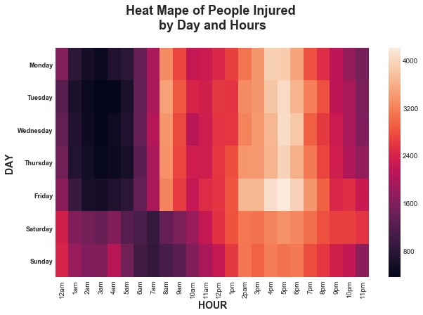

```python
#Style
plt.style.use('seaborn-darkgrid')

# Plot Size(length, width)
plt.figure(figsize=(10,6))

# Ploting the data
axes=sns.heatmap(week_hour)

# Adding title
plt.title('Heat Mape of People Injured \nby Day and Hours\n',fontsize=18,fontweight='bold')
# Adding Y Label
plt.ylabel('DAY',fontsize= 14,fontweight='bold')
# Adding X Label
plt.xlabel('HOUR',fontsize= 14,fontweight='bold')

#Modifying formet of X and Y points
plt.yticks(rotation=0,fontsize= 9,fontweight='bold')

a=axes.get_xticks().tolist()
a[0]='12am'
a[1]='1am'
a[2]='2am'
a[3]='3am'
a[4]='4am'
a[5]='5am'
a[6]='6am'
a[7]='7am'
a[8]='8am'
a[9]='9am'
a[10]='10am'
a[11]='11am'
a[12]='12pm'
a[13]='1pm'
a[14]='2pam'
a[15]='3pm'
a[16]='4pm'
a[17]='5pm'
a[18]='6pm'
a[19]='7pm'
a[20]='8pm'
a[21]='9pm'
a[22]='10pm'
a[23]='11pm'
axes.set_xticklabels(a)
```

### Plotting Injuries Per Borough:

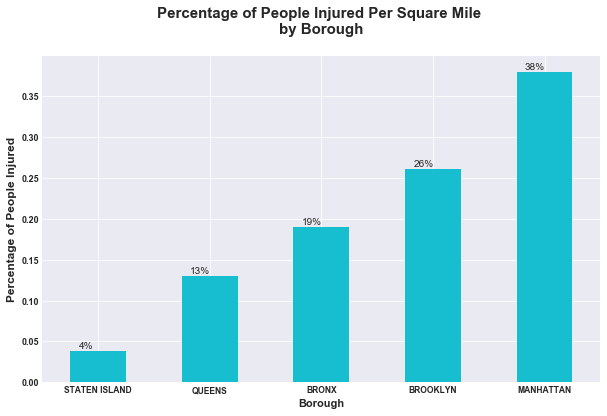

```python
#Style
plt.style.use('seaborn-darkgrid')
#plt.style.use('seaborn-whitegrid')

# Plot Size(length, width)
plt.figure(figsize=(10,6))

# Sorting and plotting
ax=Injured_pcts.sort_values().plot(kind='bar',color ="tab:cyan")

# Adding title
plt.title('Percentage of People Injured Per Square Mile \nby Borough\n',fontsize=15,fontweight='bold')
# Adding Y Label
plt.xlabel('Borough',fontsize= 11,fontweight='bold')
# Adding X Label
plt.ylabel('Percentage of People Injured',fontsize= 12,fontweight='bold')

#Modifying formet of X and Y points
plt.yticks(rotation=0,fontsize= 9,fontweight='bold')
plt.xticks(rotation=0,fontsize= 8.5,fontweight='bold')


#Adding Percentage value to our graph
for p in ax.patches:
    width, height = p.get_width(), p.get_height()
    x, y = p.get_xy()
    ax.annotate('{:.0%}'.format(height), (p.get_x()+.15*width, p.get_y() + height + 0.003))

plt.savefig('borough.png')

plt.show()
```

### Plotting Injuries Per Month:

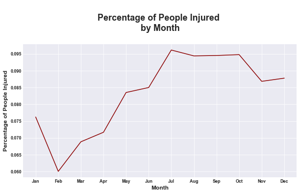

```python
# Plot Size(length, width)
plt.figure(figsize=(10,5))
#plt.style.use('ggplot')
#plt.style.use('seaborn-darkgrid')
#plt.style.use('seaborn-whitegrid')

# plotting
plt.plot(Injured_per_month,color ="darkred")

# Adding title
plt.title('\nPercentage of People Injured \nby Month\n',fontsize=18,fontweight='bold')
#Adding Y label
plt.ylabel('Percentage of People Injured',fontsize= 12,fontweight='bold')
#Adding X label
plt.xlabel('Month',fontsize= 12,fontweight='bold')

#Modifying formet of X and Y points
plt.yticks(rotation=0,fontsize= 9,fontweight='bold')
plt.xticks(rotation=0,fontsize= 9,fontweight='bold')



#Show the plot
plt.show()
```

### Plotting Injuries Per Day:

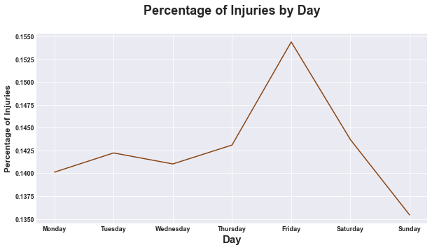

```python
# Plot Size(length, width)
plt.figure(figsize=(10,5))
#plt.style.use('ggplot')
#plt.style.use('seaborn-darkgrid')

# plotting
plt.plot(Injury_per_day,color ="saddlebrown")

# Adding title
plt.title('Percentage of Injuries by Day\n',fontsize=18,fontweight='bold')

#Adding Y label
plt.ylabel('Percentage of Injuries',fontsize= 12,fontweight='bold')
#Adding X label
plt.xlabel('Day',fontsize= 15,fontweight='bold')

#Modifying format of X and Y points
plt.yticks(rotation=0,fontsize= 9,fontweight='bold')
plt.xticks(rotation=0,fontsize= 9,fontweight='bold')




plt.show()
```

### Plotting Injuries Per Year:

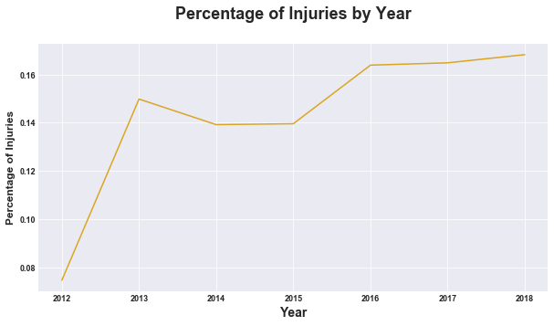

```python
# Plot Size(length, width)
plt.figure(figsize=(10,5))


#plt.style.use('ggplot')
#plt.style.use('seaborn-darkgrid')

# Plotting
plt.plot(Injure_per_year,color ="goldenrod")

# Adding Title
plt.title('Percentage of Injuries by Year\n',fontsize=18,fontweight='bold')

# Adding Y Lable
plt.ylabel('Percentage of Injuries',fontsize= 12,fontweight='bold')

# Adding X Lable
plt.xlabel('Year',fontsize= 14,fontweight='bold')

#Modifying formet of X and Y points
plt.yticks(rotation=0,fontsize= 9,fontweight='bold')
plt.xticks(rotation=0,fontsize= 9,fontweight='bold')

plt.savefig('year.png')
# Show Plot
plt.show()
```

### Plotting Total Injuries Per Month From 2013 through 2018:

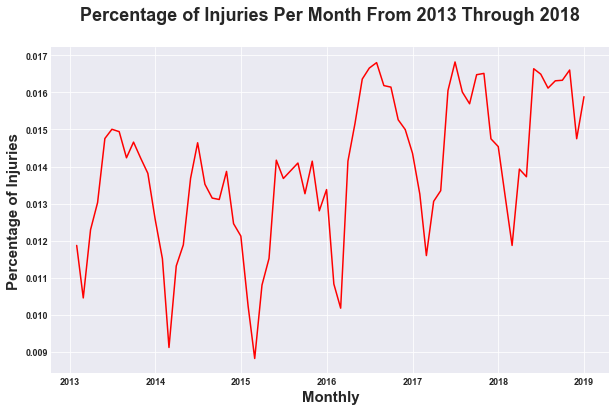

```python
plt.style.use('seaborn-darkgrid')

# Plot Size(length, width)
plt.figure(figsize=(10,6))

#plt.collisions_di.groupby(pd.Grouper(freq="M")).agg({'NUMBER_OF_PERSONS_INJURED': 'mean'}).plot()
plt.plot(Injure_per_month_year,color='red')

# Adding Title
plt.title('Percentage of Injuries Per Month From 2013 Through 2018\n',fontsize=18,fontweight='bold')

# Adding X and Y Label
plt.xlabel('Monthly',fontsize=15,fontweight='bold')
plt.ylabel('Percentage of Injuries',fontsize=15,fontweight='bold')

#Modifying formet of X and Y points
plt.yticks(rotation=0,fontsize= 9,fontweight='bold')
plt.xticks(rotation=0,fontsize= 9,fontweight='bold')


plt.show()
```

### Plotting Injuries by Hour:

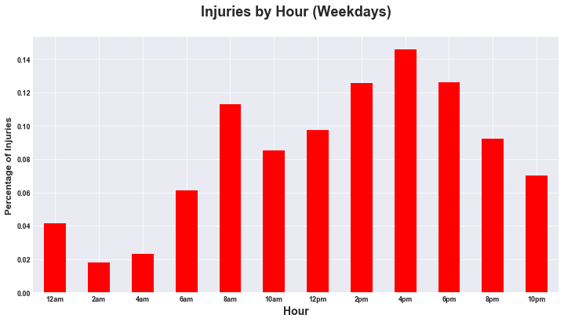

```python
# Plot Size(length, width)
plt.figure(figsize=(12,6))


#plt.style.use('ggplot')
#plt.style.use('seaborn-darkgrid')

# ploting the data
#plt.plot(Injure_per_hour_weekday,color ="red",kind ='bar')
Injure_per_hour_weekday.plot(color ="red",kind ='bar')
# Adding Title
plt.title('Injuries by Hour (Weekdays)\n',fontsize=18,fontweight='bold')

# Adding Y Lable
plt.ylabel('Percentage of Injuries',fontsize= 12,fontweight='bold')

# Adding X Lable
plt.xlabel('Hour',fontsize= 14,fontweight='bold')

#Modifying formet of X and Y points
plt.yticks(rotation=0,fontsize= 9,fontweight='bold')
plt.xticks(rotation=0,fontsize= 9,fontweight='bold')

# Show Plot
plt.show()
```

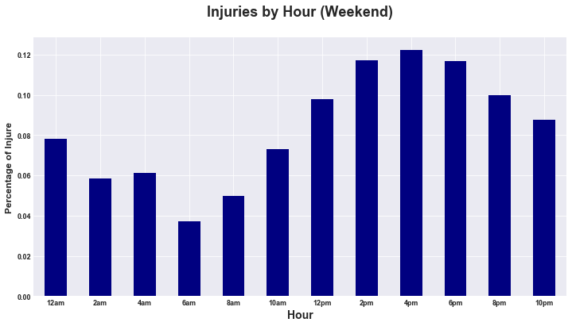

```python
# Plot Size(length, width)
plt.figure(figsize=(12,6))


#plt.style.use('ggplot')
#plt.style.use('seaborn-darkgrid')

#plotting the data
#plt.plot(Injure_per_hour_weekday,color ="red")
Injure_per_hour_weekend.plot(color ="navy",kind ='bar')
# Adding Title
plt.title('Injuries by Hour (Weekend)\n',fontsize=18,fontweight='bold')

# Adding Y Lable
plt.ylabel('Percentage of Injure',fontsize= 12,fontweight='bold')

# Adding X Lable
plt.xlabel('Hour',fontsize= 14,fontweight='bold')

#Modifying formet of X and Y points
plt.yticks(rotation=0,fontsize= 9,fontweight='bold')
plt.xticks(rotation=0,fontsize= 9,fontweight='bold')

# Show Plot
plt.show()
```

```python
!jupyter nbextension enable --py --sys-prefix ipyleaflet
```

```
Enabling notebook extension jupyter-leaflet/extension...
      - Validating: ok
```

```python
#from ipyleaflet import Map
from ipyleaflet import (Map,DrawControl)
myMap=Map(center=[40.7306,-73.935242])
dc=DrawControl(circle={'shapeOptions':{'color':'#0000FF'}})
myMap.add_control(dc)
myMap
```

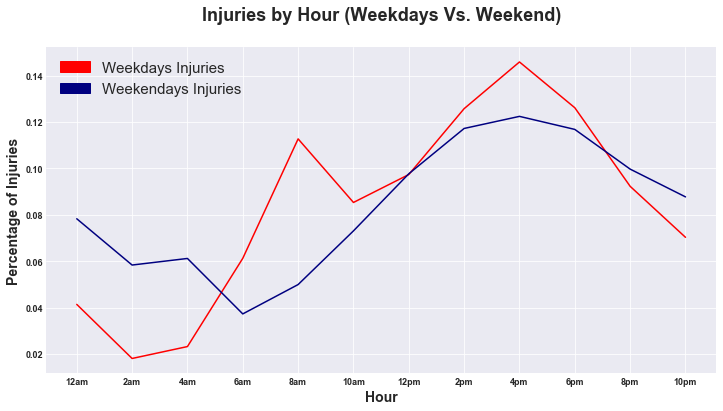

```python
# Plot Size(length, width)
plt.figure(figsize=(12,6))


#plt.style.use('seaborn-white')
#plt.style.use('seaborn-darkgrid')

# ploting the data
plt.plot(Injure_per_hour_weekday,color ="red")
plt.plot(Injure_per_hour_weekend,color ="navy")

# Adding Title
plt.title('Injuries by Hour (Weekdays Vs. Weekend)\n',fontsize=18,fontweight='bold')

# Adding Y Lable
plt.ylabel('Percentage of Injuries',fontsize= 14,fontweight='bold')

# Adding X Lable
plt.xlabel('Hour',fontsize= 14,fontweight='bold')

#Creating legend
red_patch = mpatches.Patch(label='Weekdays', color='red')
navy_patch = mpatches.Patch(label='Weekends',color='navy')

plt.legend([red_patch, navy_patch],('Weekdays Injuries', 'Weekendays Injuries'),
            loc='upper left', prop={'size':15})

#Modifying formet of X and Y points
plt.yticks(rotation=0,fontsize= 9,fontweight='bold')
plt.xticks(rotation=0,fontsize= 9,fontweight='bold')

plt.savefig('injuriesWvE.png')
# Show Plot
plt.show()
```

### Plotting Top Contributing Factors:

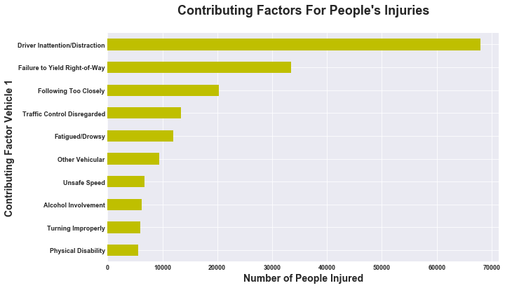

```python
# Plot Size(length, width)
plt.figure(figsize=(10,6))

#Plotting
g_factor.NUMBER_OF_PERSONS_INJURED.sort_values().plot(kind ='barh',color= 'y')

# Adding Title
plt.title('Contributing Factors For People\'s Injuries\n',fontsize=18,fontweight='bold')

# Adding X and Y Label
plt.xlabel('Number of People Injured',fontsize=14,fontweight='bold')
plt.ylabel('Contributing Factor Vehicle 1',fontsize=14,fontweight='bold')

#Modifying formet of X and Y points
plt.yticks(rotation=0,fontsize= 9,fontweight='bold')
plt.xticks(rotation=0,fontsize= 9,fontweight='bold')

plt.show()
```

### Plotting Vehicle Type Involved in Most Injuries:

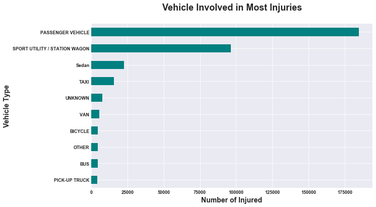

```python
# Plot Size(length, width)
plt.figure(figsize=(10,6))

# Data
g_vehicle.NUMBER_OF_PERSONS_INJURED.sort_values().plot(kind ='barh',color ='teal')

# Adding Title
plt.title('Vehicle Involved in Most Injuries\n',fontsize=18,fontweight='bold')

#Adding X and Y label
plt.xlabel('Number of Injured',fontsize=14,fontweight='bold')
plt.ylabel('Vehicle Type',fontsize=14,fontweight='bold')

#Modifying formet of X and Y points
plt.yticks(rotation=0,fontsize= 9,fontweight='bold')
plt.xticks(rotation=0,fontsize= 9,fontweight='bold')

plt.show()
```

#### Plotting Top Ten Most Dangerous Streets:

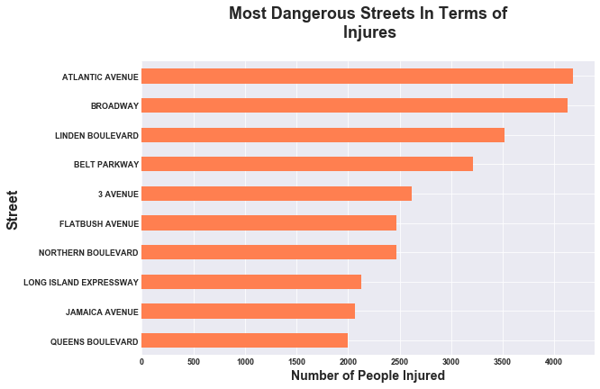

```python
# Plot Size(length, width)
plt.figure(figsize=(9,6))

# Adding Data
most_inj_street.NUMBER_OF_PERSONS_INJURED.sort_values().plot(kind="barh",color ='coral')

# Adding Title
plt.title('Most Dangerous Streets In Terms of\n Injures\n',fontsize=18,fontweight='bold')

# Adding X and Y Label
plt.xlabel('Number of People Injured',fontsize=14,fontweight='bold')
plt.ylabel('Street',fontsize=16,fontweight='bold')

#Modifying formet of X and Y points
plt.yticks(rotation=0,fontsize= 9,fontweight='bold')
plt.xticks(rotation=0,fontsize= 9,fontweight='bold')

# Show the Plot
plt.show()
```

## Geographical Plotting:

### Subsetting and Changing Data Type:

```python
# Creating subset
collision_t=collisions_df.copy()
collisions_pd = collision_t[collisions_df['LATITUDE'] != 0][['LATITUDE', 'LONGITUDE', 'DATE', 'TIME',
                                                               'BOROUGH', 'ON_STREET_NAME', 'CROSS_STREET_NAME',
                                                               'NUMBER_OF_PERSONS_INJURED', 'NUMBER_OF_PERSONS_KILLED',
                                                               'CONTRIBUTING_FACTOR_VEHICLE_1']]
# Renaming the column
collisions_pd.columns = ['Latitude', 'Longitude', 'Date', 'Time', 'Borough', 'On Street',
                         'Cross_Street', 'Persons_Injured', 'Persons_Killed', 'Contributing_Factor']

collisions_pd['Latitude'] = collisions_pd['Latitude'].astype(float)
collisions_pd['Longitude'] = collisions_pd['Longitude'].astype(float)
collisions_pd['Persons_Killed'] = collisions_pd['Persons_Killed'].astype(float)
collisions_pd['Persons_Injured'] = collisions_pd['Persons_Injured'].astype(float)



#Dividing dataset in accidents which are: fatal, non-lethal but with person damage, none of the above
killed_pd = collisions_pd[collisions_pd['Persons_Killed']!=0]
injured_pd = collisions_pd[np.logical_and(collisions_pd['Persons_Injured']!=0, collisions_pd['Persons_Killed']==0)]
nothing_pd = collisions_pd[np.logical_and(collisions_pd['Persons_Killed']==0, collisions_pd['Persons_Injured']==0)]
```

## Making Gif

```python
injured_pd_m = collisions_dt[np.logical_and(collisions_dt['NUMBER_OF_PERSONS_INJURED']!=0, collisions_dt['NUMBER_OF_PERSONS_KILLED']==0)]
```

```python
hou_inj_lola=injured_pd_m.groupby(['hour','LATITUDE', 'LONGITUDE']).agg({'NUMBER_OF_PERSONS_INJURED': 'sum'})
hou_inj_lola.head()
```

| hour | LATITUDE | LONGITUDE | NUMBER_OF_PERSONS_INJURED |
| --- | --- | --- | --- |
| 0 | 0.000000 | 0.000000 | 5.0 |
|  | 40.507880 | -74.229240 | 1.0 |
|  | 40.509044 | -74.246901 | 1.0 |
|  | 40.514414 | -74.206249 | 1.0 |
|  | 40.515358 | -74.204770 | 2.0 |

```python
hou_inj_lola = hou_inj_lola.reset_index()
hou_inj_lola.head()
```

[output not shown]

```python
'''
for i in range(24):
    #name ='injured_pd_'+ str(i)
    df=hou_inj_lola[hou_inj_lola['hour']==i]
    plt.figure(figsize=(12,8))
    plt.scatter(nothing_pd.Longitude, nothing_pd.Latitude, alpha=0.02, color='limegreen',s=1)
    plt.scatter(df.LONGITUDE, df.LATITUDE,alpha=0.7, s=killed_pd.Persons_Injured, color='red')
    #Creating legend
    #yellow_patch = mpatches.Patch( label='No Human Damage', alpha=0.4, color='yellow')
    #red_patch = mpatches.Patch( label='Personal Injury', alpha=0.4,color='red')

    #plt.legend([red_patch],('Personal Injury'),
           #loc='upper left', prop={'size':15})

     #Adjusting more settings
    plt.title('Motor Vehicle Injuries at hour:'+" "+ str(i)+'\n',fontweight='bold', size=20)
    plt.xlim((-74.26,-73.7))
    plt.ylim((40.5,40.92))
    plt.xlabel('Longitude',fontweight='bold',size=20)
    plt.ylabel('Latitude',fontweight='bold',size=20)
    plt.axis('off')
    plt.savefig('Inj_h' + str(i)+'.png')

    '''
```

### Plotting No Human Damage and Personal Injury:

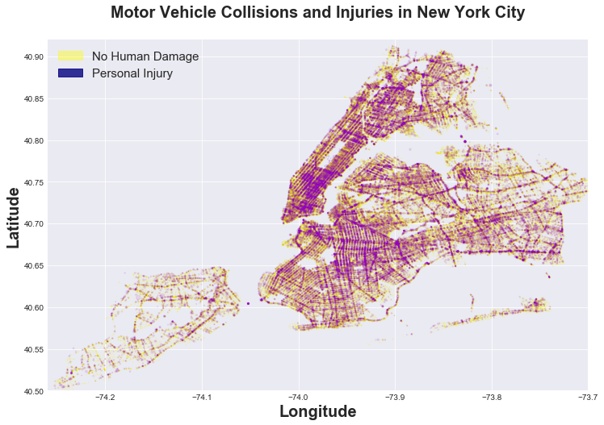

```python
#Adjusting settings
plt.figure(figsize=(12,8))

#Creating scatterplots
plt.scatter(nothing_pd.Longitude, nothing_pd.Latitude, alpha=0.02, color='yellow',s=1)
plt.scatter(injured_pd.Longitude, injured_pd.Latitude,alpha=0.09, s=killed_pd.Persons_Injured, color='darkviolet')

#Creating legend
yellow_patch = mpatches.Patch( label='No Human Damage', alpha=0.4, color='yellow')
navy_patch = mpatches.Patch( label='Personal Injury', alpha=0.8,color='navy')

plt.legend([yellow_patch, navy_patch],('No Human Damage', 'Personal Injury'),
           loc='upper left', prop={'size':15})

#Adjusting more settings
plt.title('Motor Vehicle Collisions and Injuries in New York City\n',fontweight='bold', size=20)
plt.xlim((-74.26,-73.7))
plt.ylim((40.5,40.92))
plt.xlabel('Longitude',fontweight='bold',size=20)
plt.ylabel('Latitude',fontweight='bold',size=20)
#plt.savefig('anothertry.png')

plt.show()
```

### Plotting No Human Damage, Personal Injury, and Deaths:

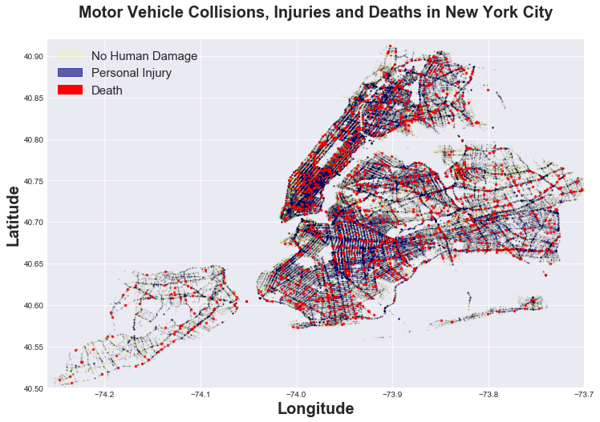

```python
#Adjusting settings
plt.figure(figsize=(12,8))

#Creating scatterplots
plt.scatter(nothing_pd.Longitude, nothing_pd.Latitude, alpha=0.01, s=.6, color='yellow')
plt.scatter(injured_pd.Longitude, injured_pd.Latitude,alpha=0.06, s=.8, color='navy')
plt.scatter(killed_pd.Longitude, killed_pd.Latitude,alpha=0.8, color='red', s=6)

#Creating a legend
yellow_patch = mpatches.Patch( label='No Human Damage', alpha=0.1, color='yellow')
navy_patch = mpatches.Patch( label='Personal Injury', alpha=0.6,color='navy')
red_patch = mpatches.Patch(color='red', label='Death')
plt.legend([yellow_patch, navy_patch, red_patch],('No Human Damage', 'Personal Injury', 'Death'),
           loc='upper left', prop={'size':15})

#Adjust more settings
plt.title('Motor Vehicle Collisions, Injuries and Deaths in New York City\n',fontweight='bold', size=20)
plt.xlim((-74.26,-73.7))
plt.ylim((40.5,40.92))
plt.xlabel('Longitude',fontweight='bold',size=20)
plt.ylabel('Latitude',fontweight='bold',size=20)
#plt.savefig('anothertry.png')

plt.show()
```

[figure not shown]

```python
#Figurs settings
plt.figure(figsize=(15,8))
#Making Subset
data1 = collisions_df[['BOROUGH', 'ON_STREET_NAME', 'LATITUDE', 'LONGITUDE']]

# Taking those ten street location
collisions1 = data1[np.logical_and(data1['ON_STREET_NAME']=='ATLANTIC AVENUE', data1['BOROUGH']=='BROOKLYN')]
collisions2 = data1[np.logical_and(data1['ON_STREET_NAME']=='NORTHERN BOULEVARD', data1['BOROUGH']=='QUEENS')]
collisions3 = data1[np.logical_and(data1['ON_STREET_NAME']=='BROADWAY', data1['BOROUGH']=='MANHATTAN')]
collisions4 = data1[np.logical_and(data1['ON_STREET_NAME']=='FLATBUSH AVENUE', data1['BOROUGH']=='BROOKLYN')]
collisions5 = data1[np.logical_and(data1['ON_STREET_NAME']=='QUEENS BOULEVARD', data1['BOROUGH']=='QUEENS')]
collisions6 = data1[np.logical_and(data1['ON_STREET_NAME']=='3 AVENUE', data1['BOROUGH']=='MANHATTAN')]
collisions7 = data1[np.logical_and(data1['ON_STREET_NAME']=='JAMAICA AVENUE', data1['BOROUGH']=='QUEENS')]
collisions8 = data1[np.logical_and(data1['ON_STREET_NAME']=='EASTERN PARKWAY', data1['BOROUGH']=='BROOKLYN')]
collisions9 = data1[np.logical_and(data1['ON_STREET_NAME']=='LINDEN BOULEVARD', data1['BOROUGH']=='BROOKLYN')]
collisions10 = data1[np.logical_and(data1['ON_STREET_NAME']=='BEDFORD AVENUE', data1['BOROUGH']=='BROOKLYN')]

#create scatterplots
plt.scatter(data1.LONGITUDE, data1.LATITUDE, color='seagreen', s=.8,alpha=.5)
plt.scatter(collisions1.LONGITUDE, collisions1.LATITUDE,  color='red',s=1)
#collisions1.LONGITUDE.plot(color='red',linewidth=2.0)
plt.scatter(collisions2.LONGITUDE, collisions2.LATITUDE, color='darkblue', s=1)
plt.scatter(collisions3.LONGITUDE, collisions3.LATITUDE,  color='magenta',s=1)
plt.scatter(collisions4.LONGITUDE, collisions4.LATITUDE, color='orange', s=1)
plt.scatter(collisions5.LONGITUDE, collisions5.LATITUDE,  color='yellow',s=1)
plt.scatter(collisions6.LONGITUDE, collisions6.LATITUDE, color='purple', s=1)
plt.scatter(collisions7.LONGITUDE, collisions7.LATITUDE, color='black',s=1)
plt.scatter(collisions8.LONGITUDE, collisions8.LATITUDE, color='blue', s=2)
plt.scatter(collisions9.LONGITUDE, collisions9.LATITUDE,  color='m',s=1)
plt.scatter(collisions10.LONGITUDE, collisions10.LATITUDE, color='cyan', s=1)


#Creatting legend
a_patch = mpatches.Patch(color='red', label='Atlantic Avenue')
b_patch = mpatches.Patch(color='darkblue', label='Northern Boulevard')
c_patch = mpatches.Patch(color='magenta', label='Broadway')
d_patch = mpatches.Patch(color='orange', label='Flatbush Avenue')
e_patch = mpatches.Patch(color='yellow', label='Queens Boulevard')
f_patch = mpatches.Patch(color='purple', label='3nd Avenue')
g_patch = mpatches.Patch(color='black', label='Jamaica Avenue')
h_patch = mpatches.Patch(color='blue', label='Eastern Parkway')
i_patch = mpatches.Patch(color='m', label='Linden Boulevard')
j_patch = mpatches.Patch(color='cyan', label='Bedford Avenue')

plt.legend([a_patch, b_patch, c_patch, d_patch, e_patch, f_patch, g_patch, h_patch, i_patch, j_patch],
           ('Atlantic Avenue', 'Northern Boulevard', 'Broadway', 'Flatbush Avenue', 'Queens Boulevard', '3nd Avenue',
            'Jamaica Avenue', 'Eastern Parkway', 'Linden Boulevard', 'Bedford Avenue'),
           loc='upper left', prop={'size':12})

#Some more settings
plt.title('Most Dangerous Street in terms of Injuries in\n New York City\n', fontweight='bold',size=22)
plt.xlim((-74.06,-73.7))
plt.ylim((40.55,40.92))
plt.xlabel('Longitude',fontweight='bold',size=15)
plt.ylabel('Latitude',fontweight='bold',size=15)
plt.savefig('map.png')
plt.axis('off')
plt.show()
```

## Building Model:

```python
# Creating indicator for weekday and weekend using numpy eval function
collisions_da["weekend"] = np.where(collisions_da.eval("weekday == 'Saturday' or weekday == 'Sunday'"), 1, 0)
```

```python
# Checking how many incedent happend in weekdays and weekends
collisions_da.weekend.value_counts()
```

```
0    1081220
1     360725
Name: weekend, dtype: int64
```

### Grouping 1st Vehicle Type involved in incident that resulted in Injury

```python
commartial_1=[
       'Pick-up Truck', 'TAXI',
       'Box Truck', 'BUS', 'VAN T', 'PK', 'Lift Boom', 'Convertible',
       'Van', 'Ambulance', 'Tractor Truck Diesel', 'Concrete Mixer',
       'Flat Bed', 'COMER', 'Tanker', 'Posta', 'Refrigerated Van',
       'Tow t', 'Bike', 'Tractor Truck Gasoline', 'Tow Truck / Wrecker',
       'Carry All', 'AMBUL', 'Motorcycle', 'Chassis Cab', 'PICK-',
       'Beverage Truck', 'School Bus', 'COM', 'Stake or Rack', 'U-Hau',
       'COMM', 'Flat Rack', 'Motorscooter', 'US Po', 'van', 'PSD',
       'MOPED', 'trail', 'LTRL', 'USPS', 'Tract', 'Sanit', 'OMR', 'TRUCK',
        'ambul', 'Forkl', 'AMBU', 'Firet', 'Box t', 'SCHOO',
       'Moped', 'FORKL', 'FIRE', 'POWER', 'usps', 'VAV', 'Open Body',
       'truck', 'ambu', 'COMME', 'schoo', 'Armored Truck', 'ELECT',
       'Multi-Wheeled Vehicle', 'FIRET', 'DELIV', 'BACKH', 'PKUP',
         'FDNY', 'none', 'UTILI', 'POSTA', 'Road',
       'PASSENGER VEHICLE', 'TRACT', 'TRAIL', 'santa', 'GOVER', 'scoot',
       'TRANS', 'US PO', 'garba', 'Truck', 'passe', 'Mail', 'MTA B',
       'stree', 'Well Driller', 'moped', 'UPS T', 'Minicycle', 'fire',
       'Motorbike', 'TRL', 'Feder', 'NISSA', 'WINNE', 'Hopper', 'Ambul',
       'Van Camper', 'AMB', 'USPS2', 'TOW T', 'UHAUL', 'PASSE', 'CMS-T',
       'Tow Truck',  'Vanette', 'other', 'SWEEP',
       'Pickup with mounted Camper',
       'DIESE', 'van c', 'HINO', 'EMS A', 'Snow Plow', 'COURI', 'Budge', 'fdny',
       'FORK', 'FLAT',  'com', 'Livestock Rack', 'Glass Rack',
       'PICKU', 'Semi-', 'AMbul', 'CHEVY', 'Golf', 'utili', 'tract',
       'DUMPT', 'PAS', 'trac', 'Comix', 'Lunch Wagon', 'MAIL', 'FREIG',
       'Elect', 'LIMO', 'Lift', 'DIRT', 'Deliv',
        'Work', 'firet', 'COMB', 'FORK-', 'Fdny',
       'PICK-UP TRUCK', 'NYPD', 'Semi',
       'CARGO', 'mta', 'Mini', 'passa', 'HORSE', 'HO', 'APORT',
       'AMBULANCE', 'U.S.', 'EN', 'sanit', 'E ONE', 'Cargo', 'vol',
       'Picku',   'BUs'
      ]

Privet_1=['SPORT UTILITY / STATION WAGON', 'Garbage or Refuse', 'Sedan',
       'PASSENGER VEHICLE',  'santa', 'scoot', 'rv', 'GATOR', 'elect', 'te', 'Pallet',
        'SPC', 'EXCAV','Motorbike',
       'SUBN/', 'EMRGN', 'COUPE', 'OIL T', 'MARK', 'RMP', 'BOAT', 'dsny',
       'e com', 'rd/s', 'flatb', 'motor', 'EMS H', 'e BIK', 'DUMP',
       'STAK', 'FED E', 'E-Bik', 'P/SH', 'Garba', 'Boom', 'TOWTR',
       'MILLI', 'SELF', 'MINI', 'Comm', 'GARBA', 'RV', 'RESCU', 'unk',
       'CHERR', 'bus', 'DELV', 'EBIKE', 'Hand', 'FORD', 'forkl', 'Porta',
       'COM.', 'SMART', 'CONCR', 'TRLR', 'UTV', 'pas', 'cate', 'UKN',
       'BICYC', 'Subn', 'DEMA-', 'spc p', 'FD NY', 'TANK', 'BED T',
       'BOBCA', 'WHEEL', 'comme', 'dump', 'DS', 'e sco', 'TR', 'TK',
       'PICK-UP TRUCK', 'TT', 'FB', 'BU', 'VN', 'CONV', 'AM',
       'MOTORCYCLE' ]
```

```python
def Vehicle_Type_1(x):
    if 'NaN' in x:
        return " "
    for i in commartial_1:
        if i in x:
            return "Commercial Vehicle"
    for i in Privet_1:
        if i in x:
            return "Privet Vehicle"
    else: return "Other"

# Applying the function that we just created
collisions_da["Vehicle_Type_1"]=collisions_da["VEHICLE_TYPE_CODE_1"].astype(str).apply(lambda x: Vehicle_Type_1(x))
```

```python
collisions_da["Vehicle_Type_1"].value_counts()
```

```
Commercial Vehicle    1249913
Privet Vehicle         102919
Other                   89113
Name: Vehicle_Type_1, dtype: int64
```

### Grouping 2nd Vehicle Type involved in incident that resulted in Injury

```python
commartial_2=['Taxi',
       'Bike', 'Tanker', 'Box Truck', 'Dump', 'Convertible', 'Van',
       'Tow Truck / Wrecker', 'Bus', 'Ambulance', 'Pick-up Truck',
       'POSTA', 'Tractor Truck Diesel',  'FIRE',
       'Garbage or Refuse', 'Flat Bed', 'Motorbike', 'MOPED', 'food',
       'Carry All', 'TRAIL', 'Concrete Mixer', 'van', 'Truck', 'AMBUL',
       'TRUCK', 'crane', 'Tractor Truck Gasoline', 'Moped', 'POWER',
       'usps', 'UTIL', 'Chassis Cab', 'Refrigerated Van',
       'Motorscooter', 'FDNY',
       'DELV', 'Grain', 'Flat Rack', 'MTA B', 'DUMP',
       'DELIV', 'armor', 'trail', 'HARVE', 'SCHOO', 'COM', 'GARAB',
       'USPS', 'schoo', 'Beverage Truck', 'Tract',
       'Bulk Agriculture',  'FLATB', 'BACKH', 'Armored Truck',
       'Fdny', 'School Bus', 'E BIK', 'CONST',
       'TRAC', 'horse', 'VAN T', 'Livestock Rack', 'MACK', 'Lift Boom',
       'Tow T', 'BOBCA', 'TRAIN', 'VAN/T',  'BUs', 'COMME',
       'truck', 'Log', 'ambul', 'SPORT UTILITY / STATION WAGON', 'G COM',
       'Multi-Wheeled Vehicle', 'Pedicab', 'forkl', 'Pallet', 'firet',
       'Cater', 'Trac', 'Comme', 'fdny', 'JohnD', 'FRE T', 'FLAT', 'bus',
       'Well Driller', 'Firet', 'trl', 'FORD', 'COMPA', 'Trail', 'TOW T',
       'us ma',  'ambu', 'BOX T', 'Motorized Home',
       'TRACK', 'sprin', 'garba', 'elect', 'Lunch Wagon', 'FREIG',
       'U-Hau', 'unkno', 'TRK',
       'axo', 'ford', 'Amb', 'mail', 'SCOOT', 'BULLD', 'NYC F', 'dumps',
       'US Po', 'nyc f', 'Ambul', 'PEDIC', 'fork',
       'Uber',  'BU',
       'TAXI',  'PICK-UP TRUCK',
       'US PO',
       'LIVERY VEHICLE']

Privet_2=['Sedan', 'Station Wagon/Sport Utility Vehicle',  'Motorcycle',  'Motorbike', 'MOPED', 'food',
       'Motorscooter',  'Subn', 'DELV', 'Grain', 'Flat Rack',  'FLATB', 'BACKH', 'PASSENGER VEHICLE',
       'TRAC', 'horse', 'VAN T', 'Livestock Rack', 'MACK', 'Lift Boom',
       'Tow T', 'BOBCA', 'TRAIN', 'VAN/T', 'Unkno', 'BUs', 'COMME',
       'Well Driller', 'Firet', 'trl', 'FORD', 'COMPA', 'Trail', 'TOW T',
       'DIG-I', 'USPST', 'P/SH', "GOV'T", 'BOXTR', 'Glass Rack', 'sedan',
       'us po', 'Crane', 'Forkl', 'PICKU', 'YELLO', 'mecha', 'const',
       'oil t', 'FOOD', 'RV', 'MOPET', 'STAK', 'Pickup with mounted Camper',  'sanit', 'Minicycle',
       'Minibike','UTLL', 'EBIKE', 'BLOCK',  'HOTDO', 'STREE', 'SANIT', 'subur',
      'LIMO/', 'TANDU', 'RUBBE', 'CAB', 'Self',
       'nissa', 'carri', 'subn', 'dump', 'TANK', 'scaff', 'ROAD', 'INTER',
       'HOE-L', 'EXCAV', 'OMNIB',
       'PALLE', 'SMALL COM VEH(4 TIRES) '
      ]
```

```python
def Vehicle_Type_2(x):
    if 'NaN' in x:
        return " "
    for i in commartial_2:
        if i in x:
            return "Commercial Vehicle"
    for i in Privet_2:
        if i in x:
            return "Privet Vehicle"
    else: return "Other"

# Applying the function that we just created
collisions_da["Vehicle_Type_2"]=collisions_da["VEHICLE_TYPE_CODE_2"].astype(str).apply(lambda x: Vehicle_Type_2(x))
```

```python
collisions_da["Vehicle_Type_2"].value_counts()
```

```
Privet Vehicle        651672
Other                 403521
Commercial Vehicle    386752
Name: Vehicle_Type_2, dtype: int64
```

### Grouping 3rd Vehicle Type involved in incident that resulted in Injury

```python
commartial_3=['Taxi',
       'Bike', 'Tanker', 'Box Truck', 'Dump', 'Convertible', 'Van',
       'Tow Truck / Wrecker', 'Bus', 'Ambulance', 'Pick-up Truck',
       'POSTA', 'Tractor Truck Diesel',  'FIRE',
       'Garbage or Refuse', 'Flat Bed', 'Motorbike', 'MOPED', 'food',
       'Carry All', 'TRAIL', 'Concrete Mixer', 'van', 'Truck', 'AMBUL',
       'TRUCK', 'crane', 'Tractor Truck Gasoline', 'Moped', 'POWER',
       'usps', 'UTIL', 'Chassis Cab', 'Refrigerated Van',
       'Motorscooter', 'FDNY',
       'DELV', 'Grain', 'Flat Rack', 'MTA B', 'DUMP',
       'DELIV', 'armor', 'trail', 'HARVE', 'SCHOO', 'COM', 'GARAB',
       'USPS', 'schoo', 'Beverage Truck', 'Tract',
       'Bulk Agriculture',  'FLATB', 'BACKH', 'Armored Truck',
       'Fdny', 'School Bus', 'E BIK', 'CONST',
       'TRAC', 'horse', 'VAN T', 'Livestock Rack', 'MACK', 'Lift Boom',
       'Tow T', 'BOBCA', 'TRAIN', 'VAN/T',  'BUs', 'COMME',
       'truck', 'Log', 'ambul', 'SPORT UTILITY / STATION WAGON', 'G COM',
       'Multi-Wheeled Vehicle', 'Pedicab', 'forkl', 'Pallet', 'firet',
       'Cater', 'Trac', 'Comme', 'fdny', 'JohnD', 'FRE T', 'FLAT', 'bus',
       'Well Driller', 'Firet', 'trl', 'FORD', 'COMPA', 'Trail', 'TOW T',
       'us ma',  'ambu', 'BOX T', 'Motorized Home',
       'TRACK', 'sprin', 'garba', 'elect', 'Lunch Wagon', 'FREIG',
       'U-Hau', 'unkno', 'TRK',
       'axo', 'ford', 'Amb', 'mail', 'SCOOT', 'BULLD', 'NYC F', 'dumps',
       'US Po', 'nyc f', 'Ambul', 'PEDIC', 'fork',
       'Uber',  'BU',
       'TAXI',  'PICK-UP TRUCK',
       'US PO',
       'LIVERY VEHICLE']

Privet_3=['Sedan', 'Station Wagon/Sport Utility Vehicle',  'Motorcycle',  'Motorbike', 'MOPED', 'food',
       'Motorscooter',  'Subn', 'DELV', 'Grain', 'Flat Rack',  'FLATB', 'BACKH', 'PASSENGER VEHICLE',
       'TRAC', 'horse', 'VAN T', 'Livestock Rack', 'MACK', 'Lift Boom',
       'Tow T', 'BOBCA', 'TRAIN', 'VAN/T', 'Unkno', 'BUs', 'COMME',
       'Well Driller', 'Firet', 'trl', 'FORD', 'COMPA', 'Trail', 'TOW T',
       'DIG-I', 'USPST', 'P/SH', "GOV'T", 'BOXTR', 'Glass Rack', 'sedan',
       'us po', 'Crane', 'Forkl', 'PICKU', 'YELLO', 'mecha', 'const',
       'oil t', 'FOOD', 'RV', 'MOPET', 'STAK', 'Pickup with mounted Camper',  'sanit', 'Minicycle',
       'Minibike','UTLL', 'EBIKE', 'BLOCK',  'HOTDO', 'STREE', 'SANIT', 'subur',
      'LIMO/', 'TANDU', 'RUBBE', 'CAB', 'Self',
       'nissa', 'carri', 'subn', 'dump', 'TANK', 'scaff', 'ROAD', 'INTER',
       'HOE-L', 'EXCAV', 'OMNIB',
       'PALLE', 'SMALL COM VEH(4 TIRES) '
      ]
```

```python
def Vehicle_Type_3(x):
    if 'NaN' in x:
        return " "
    for i in commartial_3:
        if i in x:
            return "Commercial Vehicle"
    for i in Privet_3:
        if i in x:
            return "Privet Vehicle"
    else: return "Other"

# Applying the function that we just created
collisions_da["Vehicle_Type_3"]=collisions_da["VEHICLE_TYPE_CODE_3"].astype(str).apply(lambda x: Vehicle_Type_3(x))
```

```python
collisions_da.Vehicle_Type_3.value_counts()
```

```
Other                 1326699
Privet Vehicle          73508
Commercial Vehicle      41738
Name: Vehicle_Type_3, dtype: int64
```

### Grouping 2nd Contributing Factor involved in incident that resulted in Injury

```python
alcohol_drugs_2 =[ 'Alcohol Involvement','Drugs (illegal)','Drugs (Illegal)']

human_ignorance_2=['Driver Inattention/Distraction',
       'Backing Unsafely', 'Failure to Yield Right-of-Way',
        'Driver Inexperience',  'Passenger Distraction',
       'Brakes Defective',  'Reaction to Uninvolved Vehicle',
        'Aggressive Driving/Road Rage',
       'Pedestrian/Bicyclist/Other Pedestrian Error/Confusion',
       'Outside Car Distraction',
        'Fell Asleep',
        'Failure to Keep Right',
         'Oversized Vehicle',
        'Fatigued/Drowsy',
       'Eating or Drinking',
       'Vehicle Vandalism', 'Listening/Using Headphones',
       'Prescription Medication',
       'Shoulders Defective/Improper', 'Headlights Defective',
       'Reaction to Other Uninvolved Vehicle'
       ]

traffic_law_violations_2=[ 'Cell Phone (hands-free)', 'Cell Phone (hand-Held)',
       'Cell Phone (hand-held)' ,'Other Electronic Device', 'Unsafe Lane Changing',
   'Passing Too Closely', 'Passing or Lane Usage Improper', 'Other Vehicular',
       'Unsafe Speed',  'Turning Improperly',
        'Reaction to Uninvolved Vehicle',
       'Traffic Control Disregarded',
       'Pedestrian/Bicyclist/Other Pedestrian Error/Confusion',
       'Outside Car Distraction', 'Steering Failure', 'Illnes',
       'Pavement Slippery', 'Pavement Defective', 'Fell Asleep',
       'Failure to Keep Right',
       'View Obstructed/Limited', 'Oversized Vehicle',
       'Driverless/Runaway Vehicle',
        'Using On Board Navigation Device',
       'Animals Action', 'Traffic Control Device Improper/Non-Working',
       'Accelerator Defective', 'Physical Disability', 'Texting',
       'Vehicle Vandalism', 'Listening/Using Headphones',
       'Tinted Windows', 'Other Lighting Defects', 'Tow Hitch Defective',
       'Prescription Medication', 'Windshield Inadequate',
        'Headlights Defective'

       ]


technical_fault_2=[
       'Lane Marking Improper/Inadequate'
       'Tire Failure/Inadequate', 'Glare',
        'Traffic Control Device Improper/Non-Working',
       'Accelerator Defective',
       'Vehicle Vandalism', 'Listening/Using Headphones',
       'Tinted Windows', 'Other Lighting Defects', 'Tow Hitch Defective',
        'Windshield Inadequate',
       'Headlights Defective'
       ]
```

```python
def contri_factor_2(x):
    if 'NaN' in x:
        return " "
    for i in alcohol_drugs_2:
        if i in x:
            return "Alcohol/Drugs"
    for i in human_ignorance_2:
        if i in x:
            return "Human Ignorance"
    for i in traffic_law_violations_2:
        if i in x:
            return "Traffic Law Violations"
    for i in technical_fault_2:
        if i in x:
            return "Technical Fault"
    else: return "Other"

# Applying the function that we just created
collisions_da["Primary_Reason_2"]=collisions_da["CONTRIBUTING_FACTOR_VEHICLE_2"].astype(str).apply(lambda x: contri_factor_2(x))
```

```python
collisions_da.Primary_Reason_2.value_counts()
```

```
Other                     1261774
Human Ignorance            112547
Traffic Law Violations      65927
Alcohol/Drugs                1298
Technical Fault               399
Name: Primary_Reason_2, dtype: int64
```

### Grouping 'OFF STREET' where incident took place that resulted in Injury

```python
def off_str_name(x):
    x=x.lower()
    if 'NaN' in x:
        return " "
    elif  'ave'  in x or "th" in x:
        return "Avenue"
    elif 'str' in x:
        return "Street"
    elif "ro" in x:
        return "Road"
    elif "boul" in x:
        return "Boulevard"
    else: return "Other"

# Applying the function that we just created
collisions_da["Street_Type_3"]=collisions_da["OFF_STREET_NAME"].astype(str).apply(lambda x: off_str_name(x))
```

```python
collisions_da["Street_Type_3"].value_counts()
```

[output not shown]

### Grouping 'CROSS STREET' where incident took place that resulted in Injury

```python
def cross_str_name(x):
    x=x.lower()
    if 'NaN' in x:
        return " "
    elif  'ave'  in x or "th" in x:
        return "Avenue"
    elif 'str' in x:
        return "Street"
    elif "ro" in x:
        return "Road"
    elif "boul" in x:
        return "Boulevard"
    else: return "Other"

# Applying the function that we just created
collisions_da["Street_Type_2"]=collisions_da["CROSS_STREET_NAME"].astype(str).apply(lambda x: cross_str_name(x))
```

```python
collisions_da["Street_Type_2"].value_counts()
```

```
Other        532878
Avenue       458790
Street       344076
Road          68566
Boulevard     37635
Name: Street_Type_2, dtype: int64
```

### Grouping 'ON STREET' where incident took place that resulted in Injury

```python
def str_name(x):
    x=x.lower()
    if 'NaN' in x:
        return " "
    elif  'ave'  in x or "th" in x:
        return "Avenue"
    elif 'str' in x:
        return "Street"
    elif "ro" in x:
        return "Road"
    elif "boul" in x:
        return "Boulevard"
    else: return "Other"

# Applying the function that we just created
collisions_da["Street_Type_1"]=collisions_da["ON_STREET_NAME"].astype(str).apply(lambda x: str_name(x))
```

```python
# Checking our new column values
collisions_da.Street_Type_1.value_counts()
```

```
Avenue       480353
Other        405820
Street       384291
Road         105108
Boulevard     66373
Name: Street_Type_1, dtype: int64
```

```python
# Creating indicator for injuries using numpy eval function
collisions_da["Injured_y_n"] = np.where(collisions_df.eval("NUMBER_OF_PERSONS_INJURED >= 1"), 1, 0)
```

```python
# Checking how many injuries happend
collisions_da.Injured_y_n.value_counts()
```

```
0    1168068
1     273877
Name: Injured_y_n, dtype: int64
```

```python
# Creating Subset where people didn't died
injured_pd = collisions_da[collisions_da['NUMBER_OF_PERSONS_KILLED']==0]
```

```python
sub_coll_df=injured_pd[["Injured_y_n","BOROUGH","hour","weekend",'weekday','Street_Type_1','Street_Type_2','Street_Type_3',
                        'Primary_Reason','Primary_Reason_2',"Vehicle_Type_1","Vehicle_Type_2",'Vehicle_Type_3']]
```

```python
# Looking at the data
sub_coll_df.head()
```

|  | Injured_y_n | BOROUGH | hour | weekend | weekday | Street_Type_1 | Street_Type_2 | Street_Type_3 | Primary_Reason | Primary_Reason_2 | Vehicle_Type_1 | Vehicle_Type_2 | Vehicle_Type_3 |
| --- | --- | --- | --- | --- | --- | --- | --- | --- | --- | --- | --- | --- | --- |
| 0 | 0 | MANHATTAN | 0 | 1 | Saturday | Other | Other | Avenue | Human Ignorance | Other | Commercial Vehicle | Privet Vehicle | Other |
| 1 | 1 | BROOKLYN | 0 | 1 | Saturday | Road | Street | Other | Other | Other | Commercial Vehicle | Privet Vehicle | Other |
| 2 | 0 | MANHATTAN | 0 | 1 | Saturday | Other | Other | Avenue | Human Ignorance | Human Ignorance | Commercial Vehicle | Commercial Vehicle | Other |
| 3 | 0 | MANHATTAN | 0 | 1 | Saturday | Other | Other | Street | Human Ignorance | Other | Privet Vehicle | Privet Vehicle | Other |
| 4 | 0 | MANHATTAN | 0 | 1 | Saturday | Street | Other | Other | Human Ignorance | Other | Commercial Vehicle | Privet Vehicle | Other |

### Creating Dummy variables(0 and 1)

```python
sub_coll_df_m=pd.get_dummies(sub_coll_df,columns=['BOROUGH', 'hour', 'weekday', 'Street_Type_1',
       'Street_Type_2', 'Street_Type_3', 'Primary_Reason', 'Primary_Reason_2',
       'Vehicle_Type_1', 'Vehicle_Type_2', 'Vehicle_Type_3'])
```

```python
sub_coll_df_m.head()
```

|  | Injured_y_n | weekend | BOROUGH_BRONX | BOROUGH_BROOKLYN | BOROUGH_MANHATTAN | BOROUGH_QUEENS | BOROUGH_STATEN ISLAND | hour_0 | hour_1 | hour_2 | ... | Primary_Reason_2_Traffic Law Violations | Vehicle_Type_1_Commercial Vehicle | Vehicle_Type_1_Other | Vehicle_Type_1_Privet Vehicle | Vehicle_Type_2_Commercial Vehicle | Vehicle_Type_2_Other | Vehicle_Type_2_Privet Vehicle | Vehicle_Type_3_Commercial Vehicle | Vehicle_Type_3_Other | Vehicle_Type_3_Privet Vehicle |
| --- | --- | --- | --- | --- | --- | --- | --- | --- | --- | --- | --- | --- | --- | --- | --- | --- | --- | --- | --- | --- | --- |
| 0 | 0 | 1 | 0 | 0 | 1 | 0 | 0 | 1 | 0 | 0 | ... | 0 | 1 | 0 | 0 | 0 | 0 | 1 | 0 | 1 | 0 |
| 1 | 1 | 1 | 0 | 1 | 0 | 0 | 0 | 1 | 0 | 0 | ... | 0 | 1 | 0 | 0 | 0 | 0 | 1 | 0 | 1 | 0 |
| 2 | 0 | 1 | 0 | 0 | 1 | 0 | 0 | 1 | 0 | 0 | ... | 0 | 1 | 0 | 0 | 1 | 0 | 0 | 0 | 1 | 0 |
| 3 | 0 | 1 | 0 | 0 | 1 | 0 | 0 | 1 | 0 | 0 | ... | 0 | 0 | 0 | 1 | 0 | 0 | 1 | 0 | 1 | 0 |
| 4 | 0 | 1 | 0 | 0 | 1 | 0 | 0 | 1 | 0 | 0 | ... | 0 | 1 | 0 | 0 | 0 | 0 | 1 | 0 | 1 | 0 |

5 rows × 72 columns

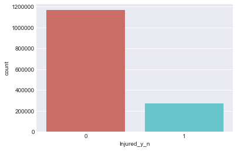

```python
sns.countplot(x="Injured_y_n",data=sub_coll_df_m,palette="hls")
```

## Implementing the model

```python
# run it once
#!pip3 install imblearn
```

```python
from sklearn.model_selection import train_test_split
from sklearn import metrics
from sklearn.metrics import classification_report,confusion_matrix
from sklearn.model_selection import GridSearchCV
from sklearn.metrics import mean_squared_error
from sklearn.feature_selection import RFE
from sklearn.linear_model import LogisticRegression
from sklearn import metrics
from sklearn.metrics import confusion_matrix
import statsmodels.api as sm
```

### Using SMOTE Algorithm (Synthetic Minority Oversampling Technique)

```python
X = sub_coll_df_m.loc[:, sub_coll_df_m.columns != 'Injured_y_n']
y = sub_coll_df_m.loc[:, sub_coll_df_m.columns == 'Injured_y_n']
```

### `Warning!!` Will take around 1.5+ hour to run this chunk of code

```python
from imblearn.over_sampling import SMOTE
os = SMOTE(random_state=0)
X_train, X_test, y_train, y_test = train_test_split(X, y, test_size=0.3, random_state=0)
columns = X_train.columns
os_data_X,os_data_y=os.fit_sample(X_train, y_train)
os_data_X = pd.DataFrame(data=os_data_X,columns=columns )
os_data_y= pd.DataFrame(data=os_data_y,columns=['y'])
```

```
C:\Anaconda\lib\site-packages\sklearn\utils\validation.py:761: DataConversionWarning: A column-vector y was passed when a 1d array was expected. Please change the shape of y to (n_samples, ), for example using ravel().
  y = column_or_1d(y, warn=True)
```

```python
# we can Check the numbers of our data
print("Length of oversampled data is ",len(os_data_X))
print("Number of no injury in oversampled data",len(os_data_y[os_data_y['y']==0]))
print("Number of injury",len(os_data_y[os_data_y['y']==1]))
print("Proportion of not injured data in oversampled data is ",len(os_data_y[os_data_y['y']==0])/len(os_data_X))
print("Proportion of injured data in oversampled data is ",len(os_data_y[os_data_y['y']==1])/len(os_data_X))
```

```
Length of oversampled data is  1633956
Number of no injury in oversampled data 816978
Number of injury 816978
Proportion of not injured data in oversampled data is  0.5
Proportion of injured data in oversampled data is  0.5
```

> Now we have a perfect balanced data and we over-sampled only on the training data, because by oversampling only on the training data, none of the information in the test data is being used to create synthetic observations, therefore, no information will bleed from test data into the model training.

```python
import statsmodels.api as sm
logit_model=sm.Logit(os_data_y,os_data_X)
result=logit_model.fit()
print(result.summary2())
```

```
                                       Results: Logit
=============================================================================================
Model:                        Logit                    Pseudo R-squared:         0.181
Dependent Variable:           y                        AIC:                      1855851.3378
Date:                         2019-05-19 15:36         BIC:                      1856725.1003
No. Observations:             1633956                  Log-Likelihood:           -9.2785e+05
Df Model:                     70                       LL-Null:                  -1.1326e+06
Df Residuals:                 1633885                  LLR p-value:              0.0000
Converged:                    0.0000                   Scale:                    1.0000
No. Iterations:               35.0000
---------------------------------------------------------------------------------------------
                                         Coef.   Std.Err.     z     P>|z|    [0.025   0.975]
---------------------------------------------------------------------------------------------
weekend                                  20.9038  67.2342    0.3109 0.7559 -110.8729 152.6804
BOROUGH_BRONX                            -0.6643   0.0076  -87.6555 0.0000   -0.6792  -0.6495
BOROUGH_BROOKLYN                         -0.4612   0.0060  -77.1440 0.0000   -0.4729  -0.4495
BOROUGH_MANHATTAN                        -0.8274   0.0070 -118.5491 0.0000   -0.8411  -0.8137
BOROUGH_QUEENS                           -0.5408   0.0063  -86.5112 0.0000   -0.5530  -0.5285
BOROUGH_STATEN ISLAND                    -1.0998   0.0128  -86.1021 0.0000   -1.1248  -1.0748
hour_0                                   -3.6883   0.0170 -217.0063 0.0000   -3.7216  -3.6550
hour_1                                   -3.8493   0.0199 -192.9799 0.0000   -3.8884  -3.8102
hour_2                                   -3.9358   0.0219 -179.4898 0.0000   -3.9788  -3.8928
hour_3                                   -3.8803   0.0228 -170.1025 0.0000   -3.9250  -3.8356
hour_4                                   -3.7526   0.0214 -175.2975 0.0000   -3.7945  -3.7106
hour_5                                   -3.8434   0.0209 -184.2861 0.0000   -3.8842  -3.8025
hour_6                                   -3.8387   0.0183 -210.1498 0.0000   -3.8745  -3.8029
hour_7                                   -3.7537   0.0169 -221.8889 0.0000   -3.7869  -3.7206
hour_8                                   -3.7767   0.0152 -247.9313 0.0000   -3.8065  -3.7468
hour_9                                   -3.9468   0.0154 -256.0334 0.0000   -3.9771  -3.9166
hour_10                                  -4.0154   0.0157 -256.1564 0.0000   -4.0461  -3.9847
hour_11                                  -3.9587   0.0155 -254.9010 0.0000   -3.9891  -3.9282
hour_12                                  -3.8806   0.0153 -253.0006 0.0000   -3.9106  -3.8505
hour_13                                  -3.8617   0.0152 -253.5897 0.0000   -3.8916  -3.8319
hour_14                                  -3.7693   0.0149 -253.2899 0.0000   -3.7985  -3.7402
hour_15                                  -3.6523   0.0149 -244.3322 0.0000   -3.6816  -3.6230
hour_16                                  -3.6987   0.0147 -251.4357 0.0000   -3.7275  -3.6698
hour_17                                  -3.6245   0.0147 -246.5195 0.0000   -3.6533  -3.5957
hour_18                                  -3.5746   0.0149 -240.3255 0.0000   -3.6038  -3.5455
hour_19                                  -3.5358   0.0152 -232.2974 0.0000   -3.5656  -3.5060
hour_20                                  -3.5157   0.0156 -225.3115 0.0000   -3.5463  -3.4851
```

[output cut: 30 more lines]

```
Primary_Reason_2_Alcohol/Drugs           -0.7518   0.0828   -9.0743 0.0000   -0.9141  -0.5894
Primary_Reason_2_Human Ignorance         -0.5246   0.0194  -27.0577 0.0000   -0.5626  -0.4866
Primary_Reason_2_Other                   -0.0291   0.0181   -1.6021 0.1091   -0.0646   0.0065
Primary_Reason_2_Technical Fault         -1.0356   0.1597   -6.4844 0.0000   -1.3487  -0.7226
Primary_Reason_2_Traffic Law Violations  -0.4513   0.0206  -21.8660 0.0000   -0.4918  -0.4109
Vehicle_Type_1_Commercial Vehicle        -0.6994   0.0160  -43.5871 0.0000   -0.7308  -0.6679
Vehicle_Type_1_Other                     -0.9641   0.0177  -54.6127 0.0000   -0.9987  -0.9295
Vehicle_Type_1_Privet Vehicle            -0.6958   0.0174  -39.8922 0.0000   -0.7300  -0.6616
Vehicle_Type_2_Commercial Vehicle        -1.2546   0.0171  -73.3354 0.0000   -1.2881  -1.2210
Vehicle_Type_2_Other                      0.0633   0.0169    3.7349 0.0002    0.0301   0.0965
Vehicle_Type_2_Privet Vehicle            -1.0402   0.0169  -61.5871 0.0000   -1.0733  -1.0071
Vehicle_Type_3_Commercial Vehicle        -0.1161   0.0203   -5.7149 0.0000   -0.1559  -0.0763
Vehicle_Type_3_Other                     -0.5667   0.0174  -32.6386 0.0000   -0.6008  -0.5327
Vehicle_Type_3_Privet Vehicle             0.0550   0.0189    2.9076 0.0036    0.0179   0.0920
=============================================================================================
```

## Logistic Regression Model Fitting

#### Now insted of `logreg.fit()`, i will use `logreg.fit(X_train, y_train)` to train our model, so that we can test our model performance

```python
from sklearn.linear_model import LogisticRegression
from sklearn import metrics
X_train, X_test, y_train, y_test = train_test_split(os_data_X, os_data_y, test_size=0.3, random_state=0)
logreg = LogisticRegression()
logreg.fit(X_train, y_train)
```

```
LogisticRegression(C=1.0, class_weight=None, dual=False, fit_intercept=True,
          intercept_scaling=1, max_iter=100, multi_class='warn',
          n_jobs=None, penalty='l2', random_state=None, solver='warn',
          tol=0.0001, verbose=0, warm_start=False)
```

## Predicting the test set results and calculating the accuracy

```python
print('Accuracy of logistic regression classifier on test set: {:.2f}'.format(logreg.score(X_test, y_test)))
```

```
Accuracy of logistic regression classifier on test set: 0.75
```

## Confusion Matrix

```python
from sklearn.metrics import confusion_matrix
y_pred = logreg.predict(X_test)
confusion_matrix = confusion_matrix(y_test, y_pred)
print(confusion_matrix)
```

```
[[204059  40942]
 [ 81443 163743]]
```

```python
from sklearn.metrics import classification_report
print(classification_report(y_test, y_pred))
```

```
              precision    recall  f1-score   support

           0       0.71      0.83      0.77    245001
           1       0.80      0.67      0.73    245186

   micro avg       0.75      0.75      0.75    490187
   macro avg       0.76      0.75      0.75    490187
weighted avg       0.76      0.75      0.75    490187
```

## ROC Curve

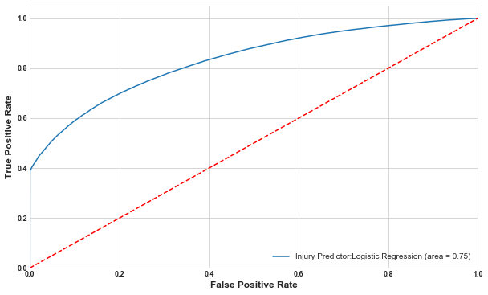

```python
from sklearn.metrics import roc_auc_score
from sklearn.metrics import roc_curve
#Style
#plt.style.use('seaborn-darkgrid')
plt.style.use('seaborn-whitegrid')
plt.figure(figsize=(10,6))


logit_roc_auc = roc_auc_score(y_test, logreg.predict(X_test))
fpr, tpr, thresholds = roc_curve(y_test, logreg.predict_proba(X_test)[:,1])
plt.plot(fpr, tpr, label='Injury Predictor:Logistic Regression (area = %0.2f)' % logit_roc_auc)

plt.plot([0, 1], [0, 1],'r--')
plt.xlim([0.0, 1.0])
plt.ylim([0.0, 1.05])
plt.xlabel('False Positive Rate',fontsize=12,fontweight='bold')
plt.ylabel('True Positive Rate',fontsize=12,fontweight='bold')
#Modifying formet of X and Y points
plt.yticks(rotation=0,fontsize= 9,fontweight='bold')
plt.xticks(rotation=0,fontsize= 9,fontweight='bold')

#plt.title('Receiver operating characteristic',fontsize=15,fontweight='bold')
plt.legend(loc="lower right")
plt.savefig('Log_ROC')
plt.show()
```